# Acoustics-Only GAMs

Yvonne Barkley

9/26/2020

Load libraries

```r
library(tidyverse)
library(mgcv)
library(corrplot)
library(geoR)
library(tidymv)
library(here)
```

# Research question:

## What environmental variables characterize sperm whale habitat?

## Hypothesis: Sperm whales are found in deep, productive offshore waters.

Load universal variables

```r
#Values used for file and directory names
survey = 'AllSurveys'
gridsize = 25
loctype = 'AcOnly'
loctype2 = 'Ac'
```

###Load data

```r
PmScaled <- readRDS(here::here( paste0('output/models/', loctype, '/data/', 'CompletePm_', gridsize, 'km_', loctype2, '_scaled.rda') ))
# add column for log effort as offset #
PmScaled$log.effort = log(PmScaled$EffArea)
```

Check correlation of covariates

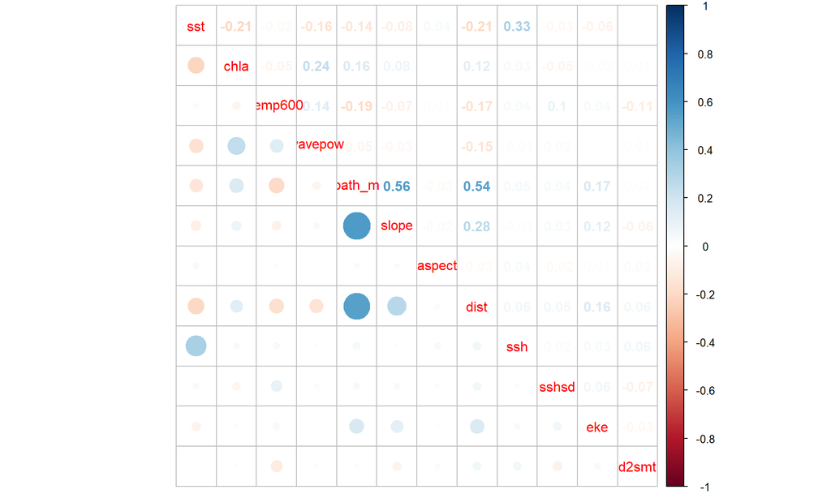

```r
require(corrplot)
corrplot.mixed(cor(PmScaled[,18:29]), upper="number", lower="circle")
```

```r
# Are all correlation coefficients < |0.6|?
abs(cor(PmScaled[,18:29])) <= 0.6
```

```
          sst  chla temp600 wavepow bath_m slope aspect  dist   ssh sshsd   eke
sst     FALSE  TRUE    TRUE    TRUE   TRUE  TRUE   TRUE  TRUE  TRUE  TRUE  TRUE
chla     TRUE FALSE    TRUE    TRUE   TRUE  TRUE   TRUE  TRUE  TRUE  TRUE  TRUE
temp600  TRUE  TRUE   FALSE    TRUE   TRUE  TRUE   TRUE  TRUE  TRUE  TRUE  TRUE
wavepow  TRUE  TRUE    TRUE   FALSE   TRUE  TRUE   TRUE  TRUE  TRUE  TRUE  TRUE
bath_m   TRUE  TRUE    TRUE    TRUE  FALSE  TRUE   TRUE  TRUE  TRUE  TRUE  TRUE
slope    TRUE  TRUE    TRUE    TRUE   TRUE FALSE   TRUE  TRUE  TRUE  TRUE  TRUE
aspect   TRUE  TRUE    TRUE    TRUE   TRUE  TRUE  FALSE  TRUE  TRUE  TRUE  TRUE
dist     TRUE  TRUE    TRUE    TRUE   TRUE  TRUE   TRUE FALSE  TRUE  TRUE  TRUE
ssh      TRUE  TRUE    TRUE    TRUE   TRUE  TRUE   TRUE  TRUE FALSE  TRUE  TRUE
sshsd    TRUE  TRUE    TRUE    TRUE   TRUE  TRUE   TRUE  TRUE  TRUE FALSE  TRUE
eke      TRUE  TRUE    TRUE    TRUE   TRUE  TRUE   TRUE  TRUE  TRUE  TRUE FALSE
d2smt    TRUE  TRUE    TRUE    TRUE   TRUE  TRUE   TRUE  TRUE  TRUE  TRUE  TRUE
        d2smt
sst      TRUE
chla     TRUE
temp600  TRUE
wavepow  TRUE
bath_m   TRUE
slope    TRUE
aspect   TRUE
dist     TRUE
ssh      TRUE
sshsd    TRUE
eke      TRUE
d2smt   FALSE
```

### KS tests

I compared the distributions of environmental data between the whales and the absences. Plots are attached in separate powerpoint. In summary, temperature at 600 m, SSH, and chlorophyll were the only variables with significantly different distributions (p-value < 0.05). However, the D statistics were close to zero (D ~ 0.1) for each, indicating that although the distributions were different, they were not that far apart. The plots also show how similar the general shape of the distributions are between where the whales were observed and where they were not observed.

### Data Splitting

Split the data into train and test sets

```r
require(dplyr)
splitdf <- function(dataframe, seed=NULL) {
    if (!is.null(seed)) set.seed(seed)
    index <- 1:nrow(dataframe)
    trainindex <- sample(index, trunc(length(index)*0.7))
    trainset <- dataframe[trainindex, ]
    testset <- dataframe[-trainindex, ]
    list(trainset=trainset,testset=testset)
}
trainAcOnly = NULL
testAcOnly = NULL
for (s in c(1641, 1303, 1604, 1705, 1706)){

 trSub <- filter(PmScaled, survey == s)

 #subset for presences and split 70/30
 pres1 <- filter(trSub, pa > 0 & sid == 999 & loc == 1)
 listPres  <- splitdf(pres1, 777) #output is list for train and test

 #subset for absences and split 70/30
 abs0  <- filter(trSub, pa == 0 )
 listAbs <- splitdf(abs0, 777)  #output is list for train and test

 #combine train data for presence and absence
 trainAll <- rbind( listPres$trainset, listAbs$trainset )

 #combine test data for presence and absence
 testAll  <- rbind( listPres$testset,  listAbs$testset  )

trainAcOnly = rbind( trainAcOnly, trainAll )
testAcOnly  = rbind( testAcOnly,  testAll)

# trainAcOnly$log.effort <- log(trainAcOnly$EffArea)
# testAcOnly$log.effort <- log(testAcOnly$EffArea)
}
saveRDS(trainAcOnly, here::here(  paste0('output/models/',loctype, '/data/Train_', gridsize, 'km_', loctype2, '_Loc.rda')  ))
saveRDS(testAcOnly, here::here(  paste0('output/models/',loctype, '/data/Test_', gridsize, 'km_', loctype2, '_Loc.rda')  ))

# nrow(dplyr::filter(trainAcOnly, trainAcOnly$pa >0))
# nrow(dplyr::filter(testAcOnly, testAcOnly$pa >0))
```

## Generalized Additive Models

The data are treated as count data, number of sperm whale encounters per cell, and we used the Tweedie distribution since it has been shown to work well when fewer positive responses exist within the data. We used thin-plate regression splines (the default basis) for the smoothers of the environmental predictors. Each smoother was limited to 3 degrees of freedom (k=3) to reduce overfitting parameters per recommendations from other studies building similar types of cetaceans distribution models.The log of the effort was included as an offset to account for the variation in effort per cell.

### 25 km spatial scale

- Knots contrained to k=3 according to literature on cetacean distribution models.
- Automatic term selection is uses an additional penalty term when determining the smoothness of the function (‘select’ argument = TRUE)..
- We excluded all non-significant variables (alpha=0.05) and refit the models until all variables were significant.
- REML is restricted maximum likelihood used to optimize the parameter estimates.

Load training and test data

```r
# trainAcOnly <- readRDS(here::here(  paste0('output/models/',loctype, '/data/Train_', gridsize, 'km_', loctype2, '.rda')  ))
# testAcOnly <- readRDS(here::here(  paste0('output/models/',loctype, '/data/Test_',   gridsize, 'km_', loctype2, '.rda')  ))
# trainLoc <- readRDS(here::here(  paste0('output/models/',loctype, '/data/Train_',   gridsize, 'km_', loctype2, '_Loc.rda')  ))
# testLoc <- readRDS(here::here(  paste0('output/models/',loctype, '/data/Test_',     gridsize, 'km_', loctype2, '_Loc.rda')  ))
# Encounters only detected by acoustics, sighting ID = S999
trainS999 <- readRDS(here::here(  paste0('output/models/',loctype, '/data/Train_',   gridsize, 'km_', loctype2, '_S999.rda')  ))
testS999 <- readRDS(here::here(  paste0('output/models/',loctype, '/data/Test_',     gridsize, 'km_', loctype2, '_S999.rda')  ))
```

## **Model Selection**

### FULL MODEL

```r
# * Does NOT include sighted acoustic encounters OR spatial smoother
require(mgcv)
twS999 <- gam(pa ~ s(bath_m, k=3) + s(dist, k=3) + s(slope, k=3) + s(d2smt, k=3) +  s(sst, k=3) + s(chla, k=3) + s(temp600, k=3) + s(ssh, k=3) + s(sshsd, k=3) + s(eke, k=3) + s(wavepow, k=3) + s(aspect, k=3) + offset(log.effort), data = trainS999, family = tw, link = 'log', select = TRUE, method = "REML")
summary(twS999)
```

```
Family: Tweedie(p=1.01)
Link function: log

Formula:
pa ~ s(bath_m, k = 3) + s(dist, k = 3) + s(slope, k = 3) + s(d2smt,
    k = 3) + s(sst, k = 3) + s(chla, k = 3) + s(temp600, k = 3) +
    s(ssh, k = 3) + s(sshsd, k = 3) + s(eke, k = 3) + s(wavepow,
    k = 3) + s(aspect, k = 3) + offset(log.effort)

Parametric coefficients:
            Estimate Std. Error t value Pr(>|t|)
(Intercept) -22.9858     0.1155    -199   <2e-16 ***
---
Signif. codes:  0 '***' 0.001 '**' 0.01 '*' 0.05 '.' 0.1 ' ' 1

Approximate significance of smooth terms:
                 edf Ref.df     F  p-value
s(bath_m)  7.491e-01      2 1.496  0.04410 *
s(dist)    4.954e-05      2 0.000  1.00000
s(slope)   3.882e-05      2 0.000  0.39337
s(d2smt)   9.609e-05      2 0.000  0.68424
s(sst)     1.123e+00      2 1.376  0.08292 .
s(chla)    8.548e-01      2 2.803  0.00908 **
s(temp600) 1.714e+00      2 9.308 1.74e-05 ***
s(ssh)     8.877e-01      2 3.908  0.00273 **
s(sshsd)   9.042e-01      2 2.741  0.01103 *
s(eke)     7.879e-01      2 1.557  0.04588 *
s(wavepow) 8.142e-05      2 0.000  1.00000
s(aspect)  1.467e+00      2 3.115  0.01433 *
---
Signif. codes:  0 '***' 0.001 '**' 0.01 '*' 0.05 '.' 0.1 ' ' 1

R-sq.(adj) =  0.0492   Deviance explained = 10.4%
-REML = 294.29  Scale est. = 1.0401    n = 3657
```

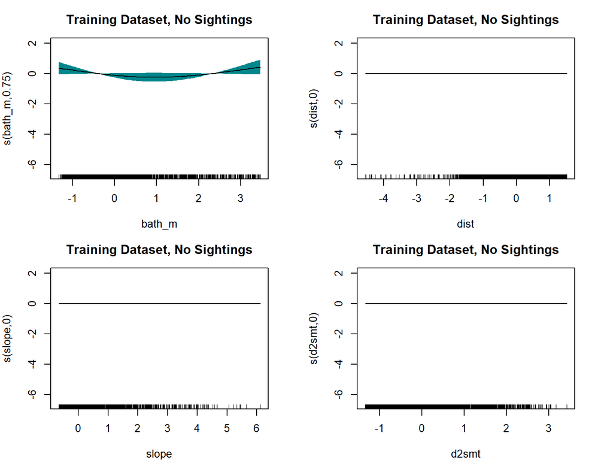

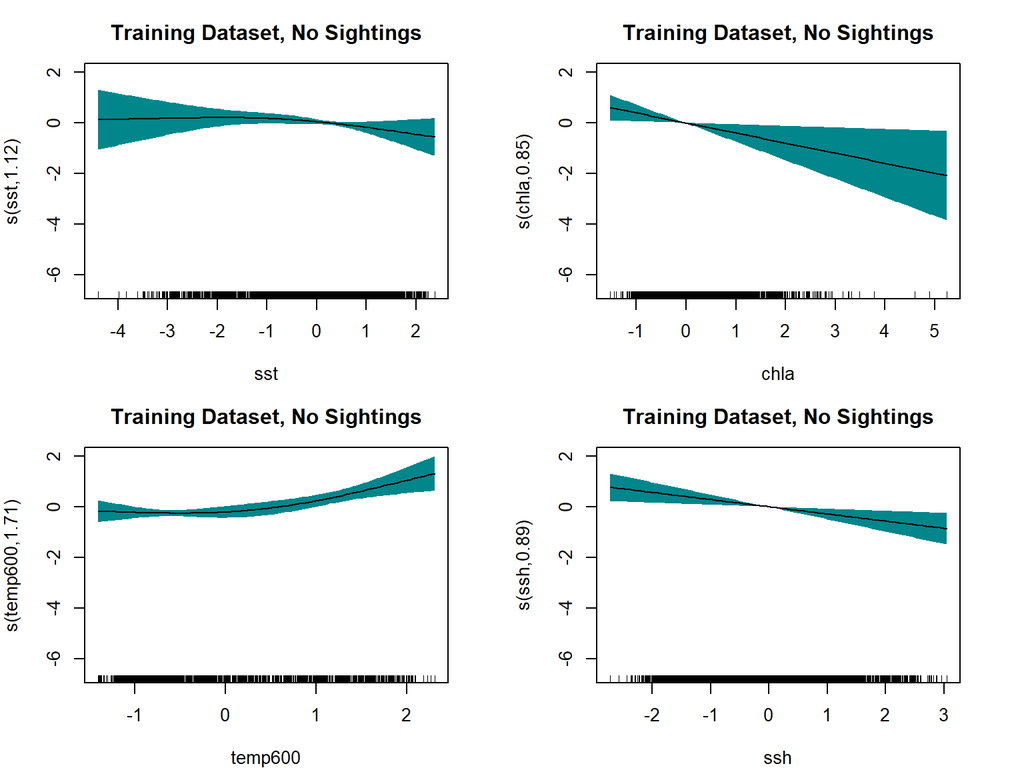

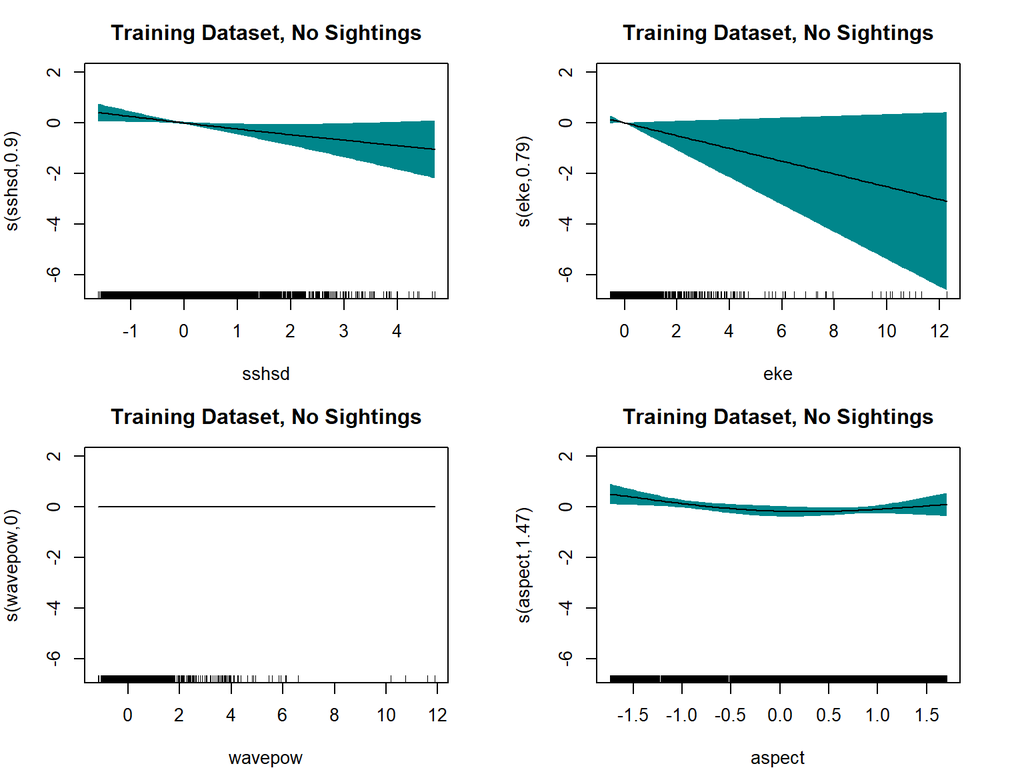

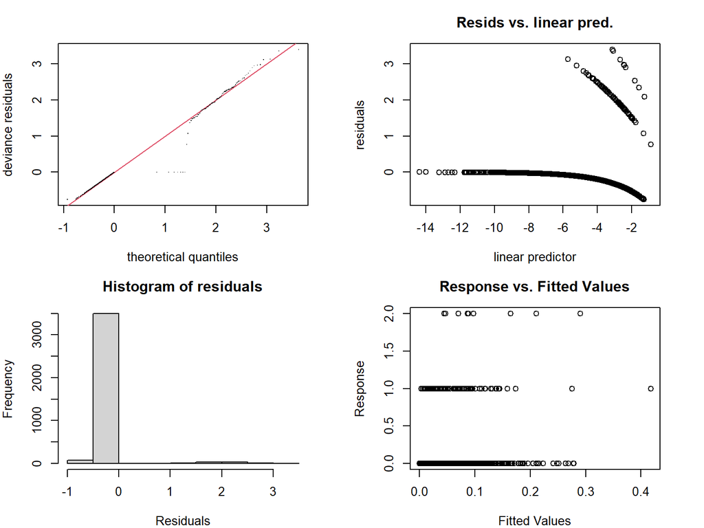

```
Method: REML   Optimizer: outer newton
full convergence after 25 iterations.
Gradient range [-0.0009810652,0.0001147095]
(score 294.2858 & scale 1.040126).
eigenvalue range [-8.262977e-06,10199.48].
Model rank =  25 / 25

Basis dimension (k) checking results. Low p-value (k-index<1) may
indicate that k is too low, especially if edf is close to k'.

                 k'      edf k-index p-value
s(bath_m)  2.00e+00 7.49e-01    0.90    0.86
s(dist)    2.00e+00 4.95e-05    0.88    0.40
s(slope)   2.00e+00 3.88e-05    0.85    0.03 *
s(d2smt)   2.00e+00 9.61e-05    0.86    0.04 *
s(sst)     2.00e+00 1.12e+00    0.87    0.13
s(chla)    2.00e+00 8.55e-01    0.86    0.06 .
s(temp600) 2.00e+00 1.71e+00    0.75  <2e-16 ***
s(ssh)     2.00e+00 8.88e-01    0.89    0.66
s(sshsd)   2.00e+00 9.04e-01    0.84  <2e-16 ***
s(eke)     2.00e+00 7.88e-01    0.88    0.39
s(wavepow) 2.00e+00 8.14e-05    0.81  <2e-16 ***
s(aspect)  2.00e+00 1.47e+00    0.89    0.44
---
Signif. codes:  0 '***' 0.001 '**' 0.01 '*' 0.05 '.' 0.1 ' ' 1
```

The stripe at the bottom left of the residuals vs. fitted values (linear predictor) corresponds to the zeros.

### REDUCE BY NS VARIABLES

- Removed distance to land, distance to seamount, slope, sst, & wave power

```r
# * Does NOT include sighted acoustic encounters

twS999b <- gam(pa ~ s(bath_m, k=3) + s(chla, k=3) + s(temp600, k=3) + s(ssh, k=3) + s(sshsd, k=3) + s(eke, k=3)  + s(aspect, k=3) + offset(log.effort), data = trainS999, family = tw, link = 'log', select = TRUE, method = "REML")
summary(twS999b)
```

```
Family: Tweedie(p=1.01)
Link function: log

Formula:
pa ~ s(bath_m, k = 3) + s(chla, k = 3) + s(temp600, k = 3) +
    s(ssh, k = 3) + s(sshsd, k = 3) + s(eke, k = 3) + s(aspect,
    k = 3) + offset(log.effort)

Parametric coefficients:
            Estimate Std. Error t value Pr(>|t|)
(Intercept) -22.9727     0.1143  -200.9   <2e-16 ***
---
Signif. codes:  0 '***' 0.001 '**' 0.01 '*' 0.05 '.' 0.1 ' ' 1

Approximate significance of smooth terms:
              edf Ref.df     F  p-value
s(bath_m)  0.7518      2 1.520 0.043472 *
s(chla)    0.8072      2 1.974 0.026500 *
s(temp600) 1.6935      2 8.726  3.5e-05 ***
s(ssh)     0.9130      2 5.200 0.000728 ***
s(sshsd)   0.8438      2 2.575 0.013294 *
s(eke)     0.7839      2 1.522 0.048642 *
s(aspect)  1.4653      2 3.115 0.014310 *
---
Signif. codes:  0 '***' 0.001 '**' 0.01 '*' 0.05 '.' 0.1 ' ' 1

R-sq.(adj) =  0.0443   Deviance explained = 9.78%
-REML = 294.78  Scale est. = 1.0403    n = 3657
```

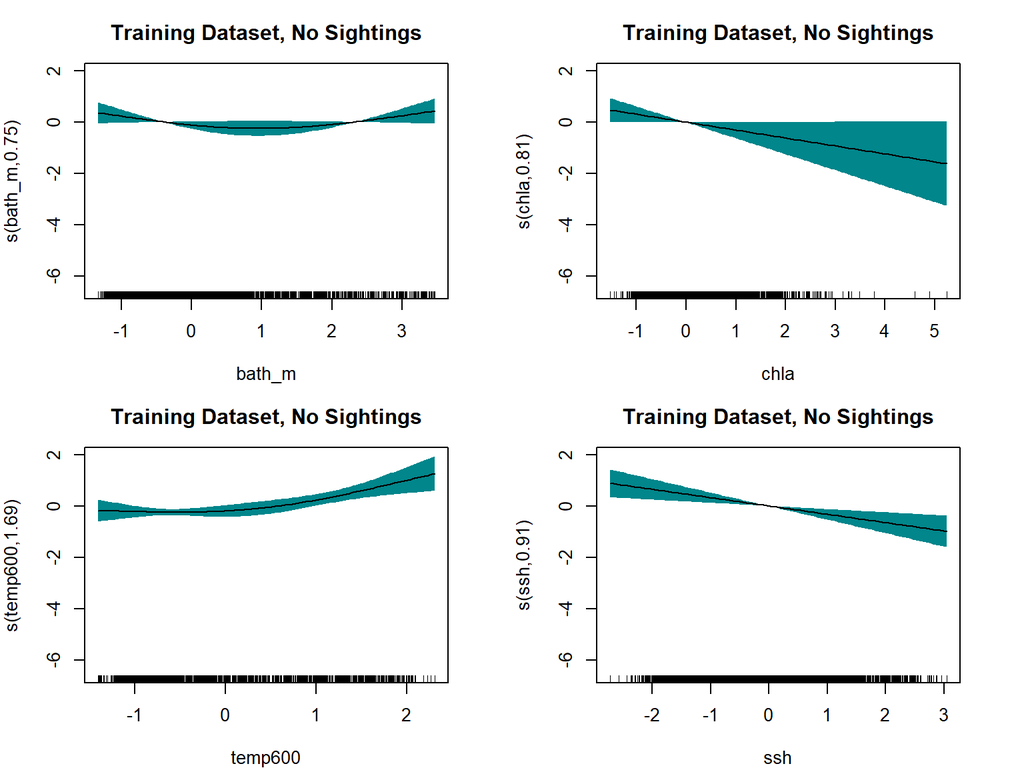

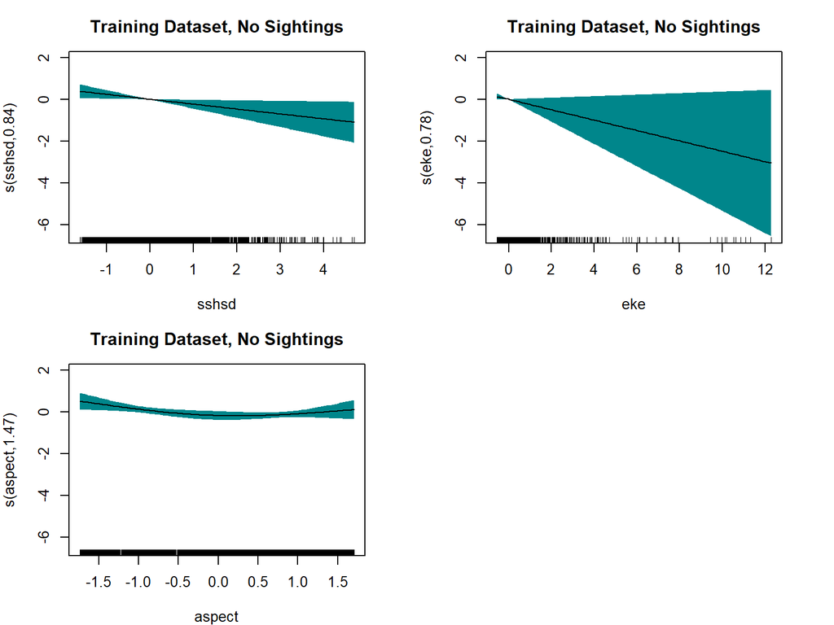

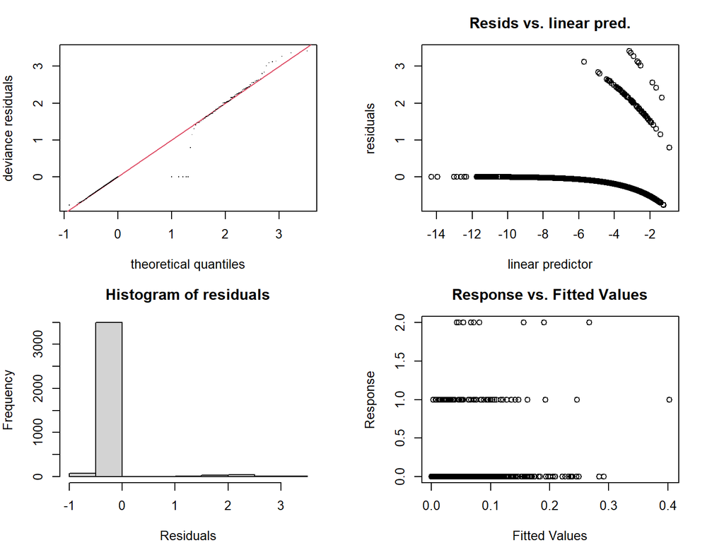

```
Method: REML   Optimizer: outer newton
full convergence after 21 iterations.
Gradient range [-0.000683161,8.25294e-05]
(score 294.7788 & scale 1.040283).
Hessian positive definite, eigenvalue range [8.660468e-06,10199.48].
Model rank =  15 / 15

Basis dimension (k) checking results. Low p-value (k-index<1) may
indicate that k is too low, especially if edf is close to k'.

              k'   edf k-index p-value
s(bath_m)  2.000 0.752    0.90   0.900
s(chla)    2.000 0.807    0.86   0.060 .
s(temp600) 2.000 1.694    0.75  <2e-16 ***
s(ssh)     2.000 0.913    0.89   0.685
s(sshsd)   2.000 0.844    0.84   0.005 **
s(eke)     2.000 0.784    0.88   0.415
s(aspect)  2.000 1.465    0.89   0.415
---
Signif. codes:  0 '***' 0.001 '**' 0.01 '*' 0.05 '.' 0.1 ' ' 1
```

##### Include 2D Lat-Lon

Includes 2D Lat-Lon smoother to account for spatial structure in the data * Notice that the temperature at 600m is no longer significant compared to the previous data * Chlorophyll and SSHsd remain significant + Does this indicate that they aren’t spatially structured and are independent of location? * The 2D smoother is fitting the spatial variation not explained by the other predictors

```r
twS999LL <- gam(pa ~ s(Longitude, Latitude) + s(bath_m, k=3) + s(dist, k=3) + s(slope, k=3) + s(d2smt, k=3) +  s(sst, k=3) + s(chla, k=3) + s(temp600, k=3) + s(ssh, k=3) + s(sshsd, k=3) + s(eke, k=3) + s(wavepow, k=3) + s(aspect, k=3) +  offset(log.effort), data = trainS999, family = tw, link = 'log', select = TRUE, method = "REML")
summary(twS999LL)
```

```
Family: Tweedie(p=1.01)
Link function: log

Formula:
pa ~ s(Longitude, Latitude) + s(bath_m, k = 3) + s(dist, k = 3) +
    s(slope, k = 3) + s(d2smt, k = 3) + s(sst, k = 3) + s(chla,
    k = 3) + s(temp600, k = 3) + s(ssh, k = 3) + s(sshsd, k = 3) +
    s(eke, k = 3) + s(wavepow, k = 3) + s(aspect, k = 3) + offset(log.effort)

Parametric coefficients:
            Estimate Std. Error t value Pr(>|t|)
(Intercept) -23.1753     0.1338  -173.3   <2e-16 ***
---
Signif. codes:  0 '***' 0.001 '**' 0.01 '*' 0.05 '.' 0.1 ' ' 1

Approximate significance of smooth terms:
                            edf Ref.df     F  p-value
s(Longitude,Latitude) 1.093e+01     29 1.993 3.62e-11 ***
s(bath_m)             5.592e-01      2 0.647   0.1178
s(dist)               1.093e-04      2 0.000   1.0000
s(slope)              6.130e-01      2 0.849   0.0894 .
s(d2smt)              1.707e-01      2 0.106   0.2426
s(sst)                1.068e-04      2 0.000   0.4040
s(chla)               7.669e-01      2 1.518   0.0415 *
s(temp600)            3.461e-01      2 0.257   0.1895
s(ssh)                1.877e-04      2 0.000   0.5108
s(sshsd)              1.326e+00      2 4.788   0.0012 **
s(eke)                7.055e-01      2 0.985   0.0916 .
s(wavepow)            5.263e-05      2 0.000   0.9997
s(aspect)             1.399e+00      2 2.684   0.0213 *
---
Signif. codes:  0 '***' 0.001 '**' 0.01 '*' 0.05 '.' 0.1 ' ' 1

R-sq.(adj) =  0.0754   Deviance explained = 17.5%
-REML = 282.73  Scale est. = 1.0381    n = 3657
```

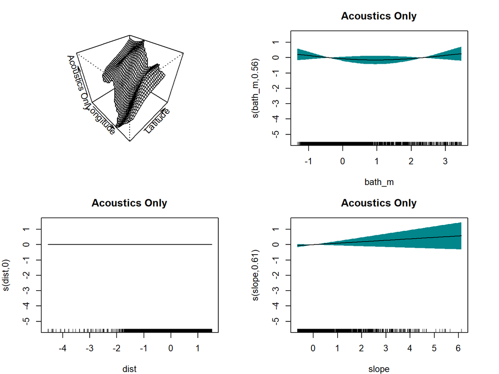

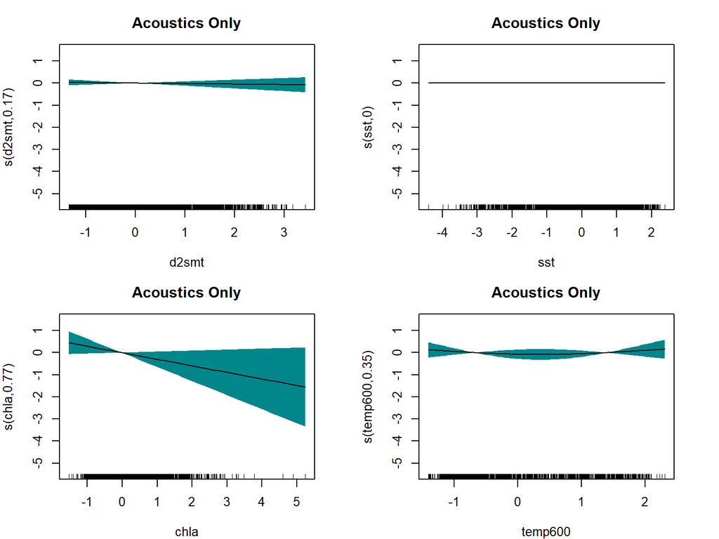

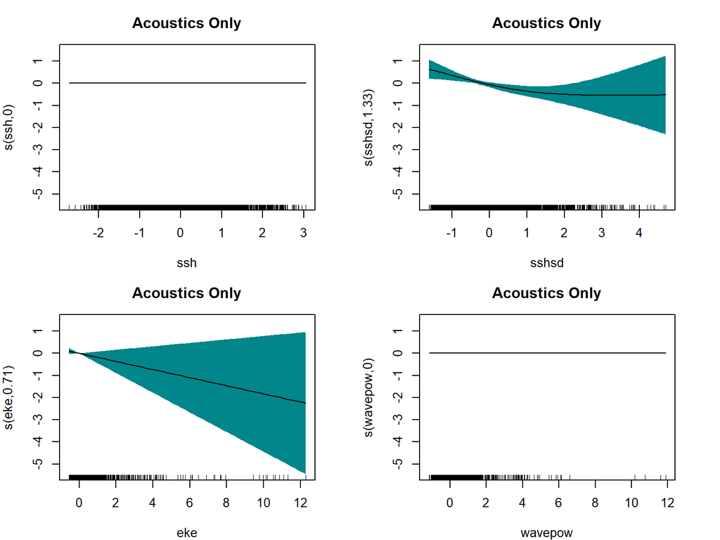

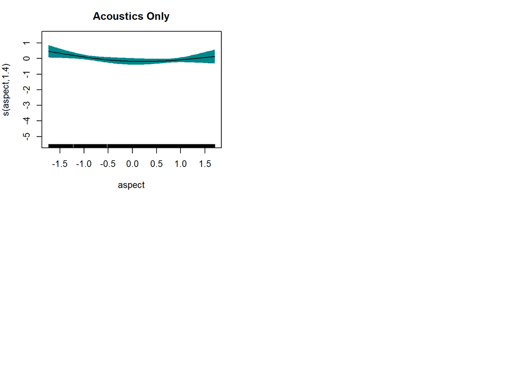

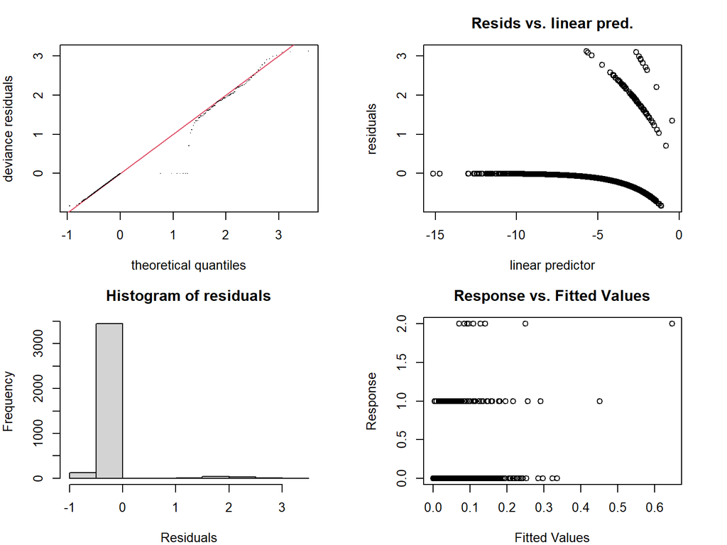

```
Method: REML   Optimizer: outer newton
full convergence after 26 iterations.
Gradient range [-0.0005548497,6.841223e-05]
(score 282.7255 & scale 1.038094).
eigenvalue range [-1.073947e-05,10199.49].
Model rank =  54 / 54

Basis dimension (k) checking results. Low p-value (k-index<1) may
indicate that k is too low, especially if edf is close to k'.

                            k'      edf k-index p-value
s(Longitude,Latitude) 2.90e+01 1.09e+01    0.89   0.510
s(bath_m)             2.00e+00 5.59e-01    0.91   0.970
s(dist)               2.00e+00 1.09e-04    0.88   0.375
s(slope)              2.00e+00 6.13e-01    0.86   0.065 .
s(d2smt)              2.00e+00 1.71e-01    0.85   0.010 **
s(sst)                2.00e+00 1.07e-04    0.86   0.095 .
s(chla)               2.00e+00 7.67e-01    0.87   0.155
s(temp600)            2.00e+00 3.46e-01    0.77  <2e-16 ***
s(ssh)                2.00e+00 1.88e-04    0.89   0.520
s(sshsd)              2.00e+00 1.33e+00    0.84  <2e-16 ***
s(eke)                2.00e+00 7.05e-01    0.88   0.420
s(wavepow)            2.00e+00 5.26e-05    0.82  <2e-16 ***
s(aspect)             2.00e+00 1.40e+00    0.88   0.330
---
Signif. codes:  0 '***' 0.001 '**' 0.01 '*' 0.05 '.' 0.1 ' ' 1
```

Predict Test Data

```r
twS999bPred <- predict.gam(twS999b, data = testS999, type='lpmatrix')
```

#### Models including only static variables

What are the effects of the static/geographic variables on sperm whale occurrence? * Resulted in only ~2% deviance explained for any iteration * Depth, slope, distance to seamount were significant, no aspect included * Resulted in only ~3% deviance explained for any iteration WITH aspect, same sig variables

#### Models only including dynamic variables to evaluate how well they explain

- Resulted in ~10% explained deviance, all variables significant except wave power